# Error exercise for Alison

Alex

2019-10-11

Functions to flip a coin, flip a coin a bunch of times, and return the sample proportion of heads when flipping a coin a bunch of times, respectively.

```r
# Function to flip the coin once, and return 1 if heads and 0 if tails.
# To simulate a random variable which takes on values of 1 with probability
# 1/2 and 0 with probability 1/2, I will simulate a U ~ Unif(0,1) random variable,
# and then return an indicator of whether U > 1/2, which happens with probability
# 1/2.
flip_the_coin_once <- function() {
  # This function takes no arguments.
  # It uses random number generation to return 1 with probability 1/2
  # and 0 with probability 1/2
  as.numeric(runif(1) > 1/2)
}

# Function to flip the coin n times and return a vector containing
# the results of each flip
flip_the_coin_more_than_once <- function(n) {
  # n: number of times to flip the coin.
  # Returns a vector of length n containing the results of each flip.
  out <- numeric(n)
  for (i in 1:n) {
    out[i] <- flip_the_coin_once()
  }
  out
}

# Function to flip the coin n times and compute the
# sample proportion of heads
sample_proportion_of_heads <- function(n) {
  # n: number of times to flip the coin
  # Returns a number representing the sample proportion of heads
  # in n flips
  mean(flip_the_coin_more_than_once(n))
}
```

Try it out. The following three seeds give $\hat{p} = 0.2, 0.8,$ and $0.5$:

```r
set.seed(4178032) # Pick some arbitrary number. Gives the same random numbers every time.
# I do this for reproducibility, because this is a book.
sample_proportion_of_heads(10)
```

```
## [1] 0.2
```

```r
set.seed(469096)
sample_proportion_of_heads(10)
```

```
## [1] 0.8
```

```r
set.seed(80798)
sample_proportion_of_heads(10)
```

```
## [1] 0.5
```

Now, have them flip it $10$ times, a bunch of times, and illustrate the empirical sampling distribution of $\hat{p}$:

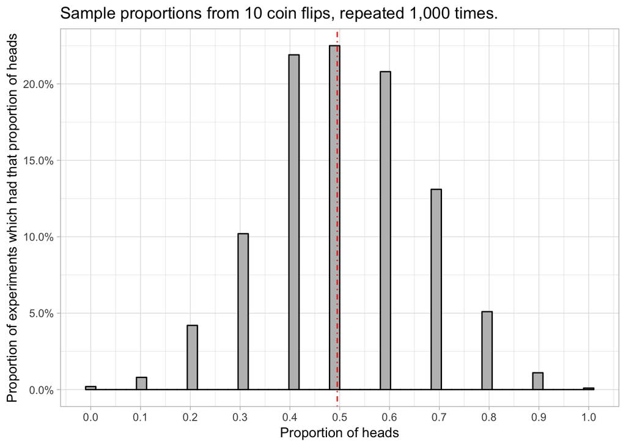

```r
set.seed(41679)
N <- 1000 # Number of times to repeat the experiment
sample_proportions <- numeric(N) # Vector to store the results
for (i in 1:N) sample_proportions[i] <- sample_proportion_of_heads(10) # Perform the experiments

# Plot them
tibble(x = sample_proportions) %>%
  ggplot(aes(x = x)) +
  theme_light() +
  geom_histogram(aes(y = ..count../sum(..count..)),bins = 50,colour = "black",fill = "grey") +
  labs(title = stringr::str_c("Sample proportions from 10 coin flips, repeated ",scales::comma(N)," times."),
       x = "Proportion of heads",
       y = "Proportion of experiments which had that proportion of heads"
  ) +
  scale_x_continuous(breaks = seq(0,1,by=.1)) +
  scale_y_continuous(labels = scales::percent_format()) +
  geom_vline(xintercept = .495,colour = "red",linetype = "dotdash")
```

This introduces the idea that a good way to measure how “good” an estimator is is by using properties of its sampling distribution to quantify how close it is to the true value, on average or in probability etc.

Now have them run it again, for different numbers of flips per experiment. Use this to introduce the relationship between the size of the experiment and the sampling distribution of the estimator, and the precision of the resulting estimates.

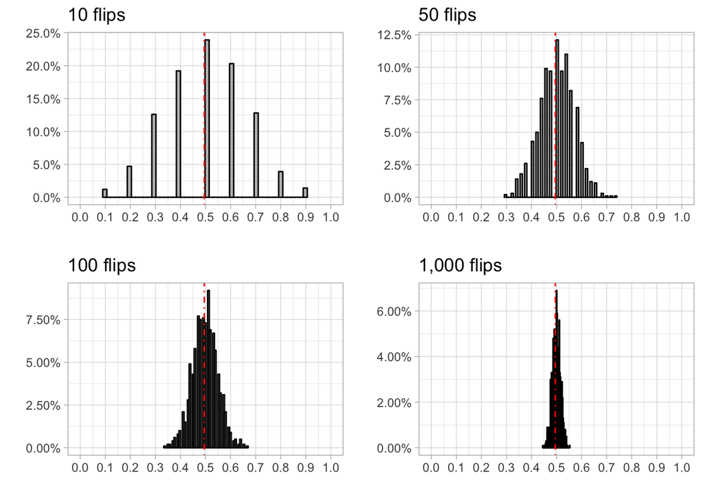

```r
set.seed(64239)
N <- 1000 # Number of times to repeat the experiment
n <- c(10,50,100,1000) # Numbers of times to flip the coin
sample_proportions <- tibble(
  n = rep(n,N),
  p = numeric(length(n))
) # Dataframe to store the results
for (i in 1:nrow(sample_proportions)) {
  sample_proportions[i,"p"] <- sample_proportion_of_heads(
    as.numeric(
      sample_proportions[i,"n"]
      )
    )
}

# Plot them
plotlst <- list()
for (size in n) {
  plotlst[[as.character(size)]] <- sample_proportions %>%
    filter(n == size) %>%
    ggplot(aes(x = p)) +
    theme_light() +
    geom_histogram(aes(y = ..count../sum(..count..)),bins = 50,colour = "black",fill = "grey") +
    labs(title = stringr::str_c(scales::comma(size)," flips"),x = " ",y = " ") +
    scale_x_continuous(breaks = seq(0,1,by=.1)) +
    scale_y_continuous(labels = scales::percent_format()) +
    geom_vline(xintercept = .495,colour = "red",linetype = "dotdash") +
    coord_cartesian(xlim = c(0,1))
}

cowplot::plot_grid(plotlist = plotlst,nrow = 2)
```

Compute how often $\hat{p}$ is more than $0.05$ away from $0.5$ for each sample size:

```r
howfaristoofar <- .05
sample_proportions %>%
  mutate(howfaraway = abs(p - .5),
         fartherthaniwant = as.numeric(howfaraway > howfaristoofar)) %>%
  group_by(n) %>%
  summarize(toofar = mean(fartherthaniwant)) %>%
  mutate(toofar = scales::percent(toofar)) # Pretty
```

```
## # A tibble: 4 x 2
##       n toofar
##   <dbl> <chr>
## 1    10 76.1%
## 2    50 47.6%
## 3   100 31.3%
## 4  1000 0.2%
```

They can play around with this.